# STAT 240 Discussion 2

## Exoplanet Data

We will be working with data on exoplanets; exoplanets are planets orbiting stars outside our Solar System. The data were pulled from the [NASA Exoplanet Archive](https://exoplanetarchive.ipac.caltech.edu/index.html) on September 3, 2020.

The variables we will be working with are defined below. If you want more details, please see the exoplanet archive [data column definitions](https://exoplanetarchive.ipac.caltech.edu/docs/API_PS_columns.html) (using the column names in the raw data).

`planet` = Planet Name  
`method` = Method by which the planet was first identified  
`year` = Discovery Year (the year it was discovered)  
`number` = Number of Planets  
`radius` = Planet Radius (units: Earth Radius)  
`mass` = Approximate or Minimum Planet Mass (units: Earth Mass)

## Questions

### Question 1

> Make a scatter plot with `radius` (the estimate of the planet radius) on the x-axis and `mass` (the estimate of the planet mass) on the vertical axis. The `scale_y_log10()` and `scale_y_log10()` are added to change the axis values to a `log10()` scale.

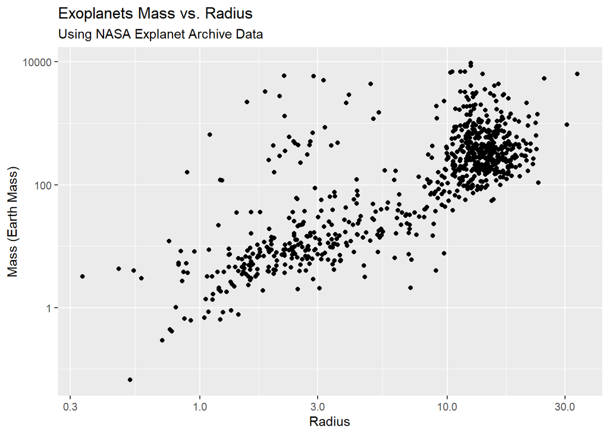

```r
## COMPLETE CODE TO MAKE THIS PLOT
ggplot(planets) +
  scale_y_log10() +
  scale_x_log10() +
  xlab("Radius") +
  ylab("Mass (Earth Mass)") +
  ggtitle("Exoplanets Mass vs. Radius",
          subtitle="Using NASA Explanet Archive Data")+
  geom_point(aes(x=radius,y=mass))
```

### Question 2

> Make a scatter plot like the previous problem, but use the `color` aesthetic for `method` (discovery method).

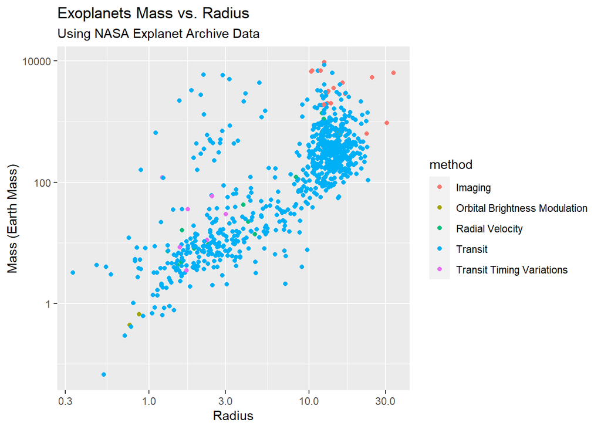

```r
## COMPLETE CODE TO MAKE THIS PLOT
ggplot(planets) +
  scale_y_log10() +
  scale_x_log10() +
  xlab("Radius") +
  ylab("Mass (Earth Mass)") +
  ggtitle("Exoplanets Mass vs. Radius",
          subtitle="Using NASA Explanet Archive Data")+
  geom_point(aes(x=radius,y=mass,color = method))
```

### Question 3

- Which discovery method was used to detect the most exoplanets in our `planet` data frame?
- What general pattern do you notice between planet mass and radius?
- What is the estimated radius (approximately) of the most massive planet included on the plot?

### Question 4

> Another way to display differences by discovery method is to separate the plot into multiple panels (or facets) and plot different subsets of the data in each. We are going to look at planet mass versus discovery year. Add a comment to say what the code on the next line does where indicated.

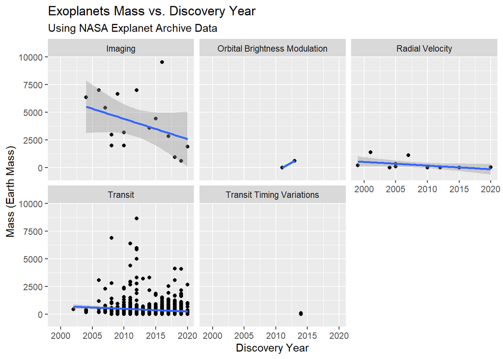

```r
ggplot(planets, aes(x=year,y=mass)) +
  geom_point() +
  ## Creates a line of best fit for the points in the graph
  # Response:
  geom_smooth(method="lm") +
  ## Creates a different graph for each method
  # Response:
  facet_wrap(~method) +
  xlab("Discovery Year") +
  ylab("Mass (Earth Mass)") +
  ggtitle("Exoplanets Mass vs. Discovery Year",
          subtitle="Using NASA Explanet Archive Data")
```